# Cams1_PM10_NeuralNet

ishmam shahid

8/25/2020

Loading all the required Libraries

```r
library(neuralnet)
library(caret)
library(ggplot2)
library(imager)
library(gridExtra)
```

Load data, subset from 2014-2018, derive the proper sequence of dates

```r
data <- read.csv("CAMS1-SANGSAD all date.csv")
data<-data[366:2191,]
data<-data[-1]
date<- seq(as.Date('2014-01-01'),as.Date('2018-12-31'),by = 1)
date<-as.POSIXct(strptime(date, format ="%Y-%m-%d" ))
data<-cbind(date,data)
summary(data)
```

```
##       date                          Temp             ws
##  Min.   :2014-01-01 00:00:00   Min.   :13.00   Min.   : 0.000
##  1st Qu.:2015-04-02 06:00:00   1st Qu.:23.40   1st Qu.: 2.000
##  Median :2016-07-01 12:00:00   Median :27.50   Median : 2.000
##  Mean   :2016-07-01 12:00:00   Mean   :26.33   Mean   : 2.241
##  3rd Qu.:2017-09-30 18:00:00   3rd Qu.:29.50   3rd Qu.: 3.000
##  Max.   :2018-12-31 00:00:00   Max.   :34.40   Max.   :12.000
##     SolarRad         Rainfall          Humidity          PM10
##  Min.   :  0.00   Min.   :  0.000   Min.   :34.00   Min.   :  8.50
##  1st Qu.: 94.36   1st Qu.:  0.000   1st Qu.:66.00   1st Qu.: 52.82
##  Median :123.61   Median :  0.000   Median :73.00   Median : 85.82
##  Mean   :123.15   Mean   :  5.232   Mean   :72.19   Mean   :116.83
##  3rd Qu.:154.71   3rd Qu.:  2.000   3rd Qu.:80.00   3rd Qu.:180.93
##  Max.   :478.57   Max.   :149.000   Max.   :97.00   Max.   :412.79
##      PM2.5
##  Min.   :  0.00
##  1st Qu.: 26.80
##  Median : 48.83
##  Mean   : 71.55
##  3rd Qu.:110.23
##  Max.   :315.62
```

Aggregate weekly data from daily averaged data

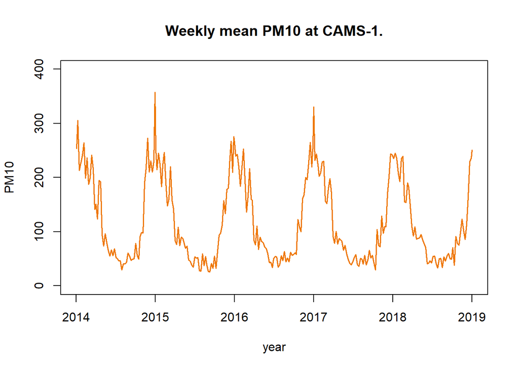

```r
# calculate weekly means
Weekly_Means <- aggregate(data, format(data["date"],"%Y-%W"),
                               mean, na.rm = TRUE)
# derive the proper sequence of dates
Weekly_Means$date <- seq(min(data$date), max(data$date), length = nrow(Weekly_Means))
Weekly_Means<-Weekly_Means[-1]
plot(Weekly_Means$date, Weekly_Means[, "PM10"],
     type = "l",
     lwd = 1.5,
     pch = 16,
     col = "darkorange2",
     xlab = "year",
     ylab = "PM10",
     ylim = c(0, 400),
     main = "Weekly mean PM10 at CAMS-1.")
```

```r
data<-data[-1]
dataPM10<- data[-7]
normalize <- function(x) {
  return((x - min(x)) / (max(x) - min(x)))
}

dataPM10_norm <- as.data.frame(lapply(dataPM10, normalize))
summary(dataPM10_norm$PM10)
```

```
##    Min. 1st Qu.  Median    Mean 3rd Qu.    Max.
##  0.0000  0.1096  0.1912  0.2680  0.4265  1.0000
```

```r
summary(dataPM10$PM10)
```

```
##    Min. 1st Qu.  Median    Mean 3rd Qu.    Max.
##    8.50   52.82   85.82  116.83  180.93  412.79
```

```r
dataPM10_train <- dataPM10_norm[1:1461, ]
dataPM10_test <- dataPM10_norm[1462:1826, ]
```

Building neural network models of varying number of neurons

Since these computations take longer time on computers to run, we will load the previously produced models on the workspace. The codes for creating the neural network models are given in the RMarkdown file for reference.

```r
load("NeuralNet_models.RData")
```

Computing the predicted values using unseen test data on the trained models

```r
model_results_3 <- compute(model_3, dataPM10_test[1:5])
model_results_5 <- compute(model_5, dataPM10_test[1:5])
model_results_7 <- compute(model_7, dataPM10_test[1:5])
model_results_9 <- compute(model_9, dataPM10_test[1:5])
model_results_12 <- compute(model_12, dataPM10_test[1:5])
model_results_15 <- compute(model_15, dataPM10_test[1:5])
model_results_20 <- compute(model_20, dataPM10_test[1:5])

predicted3 <- model_results_3$net.result
predicted5 <- model_results_5$net.result
predicted7 <- model_results_7$net.result
predicted9 <- model_results_9$net.result
predicted12 <- model_results_12$net.result
predicted15 <- model_results_15$net.result
predicted20 <- model_results_20$net.result
```

Converting all values to their original scale

```r
predicted3 <- model_results_3$net.result*(max(dataPM10$PM10)-min(dataPM10$PM10))+min(dataPM10$PM10)
predicted5 <- model_results_5$net.result*(max(dataPM10$PM10)-min(dataPM10$PM10))+min(dataPM10$PM10)
predicted7 <- model_results_7$net.result*(max(dataPM10$PM10)-min(dataPM10$PM10))+min(dataPM10$PM10)
predicted9 <- model_results_9$net.result*(max(dataPM10$PM10)-min(dataPM10$PM10))+min(dataPM10$PM10)
predicted12 <- model_results_12$net.result*(max(dataPM10$PM10)-min(dataPM10$PM10))+min(dataPM10$PM10)
predicted15 <- model_results_15$net.result*(max(dataPM10$PM10)-min(dataPM10$PM10))+min(dataPM10$PM10)
predicted20 <- model_results_20$net.result*(max(dataPM10$PM10)-min(dataPM10$PM10))+min(dataPM10$PM10)

actual_test <- (dataPM10_test$PM10)*(max(dataPM10$PM10)-min(dataPM10$PM10))+min(dataPM10$PM10)
```

Incase negative values predicted, these are converted to zero instead

```r
predicted3<-  ifelse(predicted3 < 0, 0, predicted3)
predicted5<-  ifelse(predicted5 < 0, 0, predicted5)
predicted7<-  ifelse(predicted7 < 0, 0, predicted7)
predicted9<-  ifelse(predicted9 < 0, 0, predicted9)
predicted12<-  ifelse(predicted12 < 0, 0, predicted12)
predicted15<-  ifelse(predicted15 < 0, 0, predicted15)
predicted20<-  ifelse(predicted20 < 0, 0, predicted20)
```

A data frame is constructed to properly visualize the performance metrics of the models

```r
metrics_df<-rbind(cbind(Cor.Coeff=cor(predicted3,actual_test),
                        data.frame(as.list(postResample(predicted3,actual_test)))),
                  cbind(Cor.Coeff=cor(predicted5,actual_test),
                        data.frame(as.list(postResample(predicted5,actual_test)))),
                  cbind(Cor.Coeff=cor(predicted7,actual_test),
                        data.frame(as.list(postResample(predicted7,actual_test)))),
                  cbind(Cor.Coeff=cor(predicted9,actual_test),
                        data.frame(as.list(postResample(predicted9,actual_test)))),
                  cbind(Cor.Coeff=cor(predicted12,actual_test),
                        data.frame(as.list(postResample(predicted12,actual_test)))),
                  cbind(Cor.Coeff=cor(predicted15,actual_test),
                        data.frame(as.list(postResample(predicted15,actual_test)))),
                  cbind(Cor.Coeff=cor(predicted20,actual_test),
                        data.frame(as.list(postResample(predicted20,actual_test)))))



row.names(metrics_df)<-c("3 Neurons","5 Neurons","7 Neurons","9 Neurons","12 Neurons",
                         "15 Neurons","20 Neurons")



metrics_df
```

```
##            Cor.Coeff     RMSE  Rsquared      MAE
## 3 Neurons  0.8152006 45.03677 0.6645520 32.53434
## 5 Neurons  0.7952116 48.55203 0.6323615 35.55348
## 7 Neurons  0.7981110 47.20719 0.6369812 34.02112
## 9 Neurons  0.8043068 46.71212 0.6469095 33.40991
## 12 Neurons 0.7941503 47.91953 0.6306748 33.89636
## 15 Neurons 0.7993522 47.08039 0.6389639 33.83265
## 20 Neurons 0.8062138 45.93980 0.6499807 33.16318
```

Based on the error metrics the model with 3 neurons performs best. The model architecture is shown

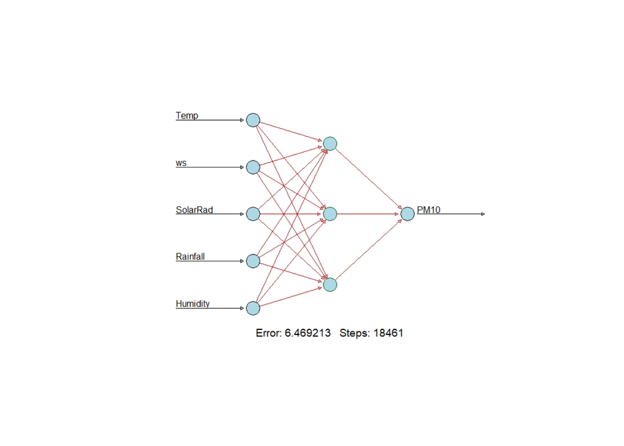

```r
#plot(model_3,show.weights = F,col.hidden = 'darkgreen',intercept = F,
     #col.hidden.synapse = 'red', fill="lightblue")


im <- load.image('network.jpeg')
plot(im,axes = F)
```

#Plot actual and predicted values vs the testing period

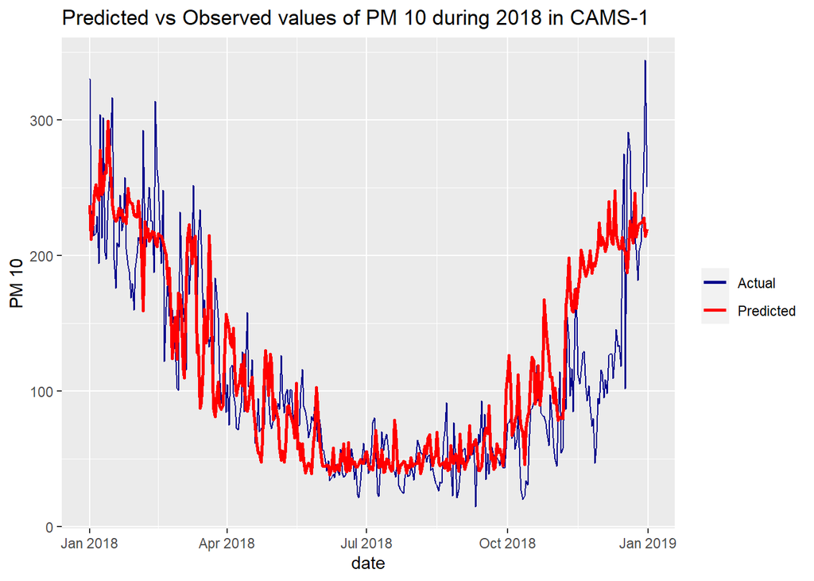

```r
test_date<- seq(as.Date('2018-01-01'),as.Date('2018-12-31'),by = 1)
test_date<-as.POSIXct(strptime(test_date, format ="%Y-%m-%d" ))
#rm(plot_df)
predicted3<-as.numeric(predicted3)
#rm(plot_df)
plot_df<-data.frame(test_date,actual_test,predicted3)
colnames(plot_df)<-c("date","actual","predicted")


p_10_1<- ggplot(data = plot_df, aes(x = date)) +
  geom_line(aes(y = actual, colour = "Actual")) +
  geom_line(aes(y = predicted, colour = "Predicted"),lwd=1) +

  scale_colour_manual("",
                      breaks = c("Actual", "Predicted"),
                      values = c("darkblue", "red")) +
  labs( y = "PM 10", title = "Predicted vs Observed values of PM 10 during 2018 in CAMS-1")

p_10_1
```

Correlation Plot

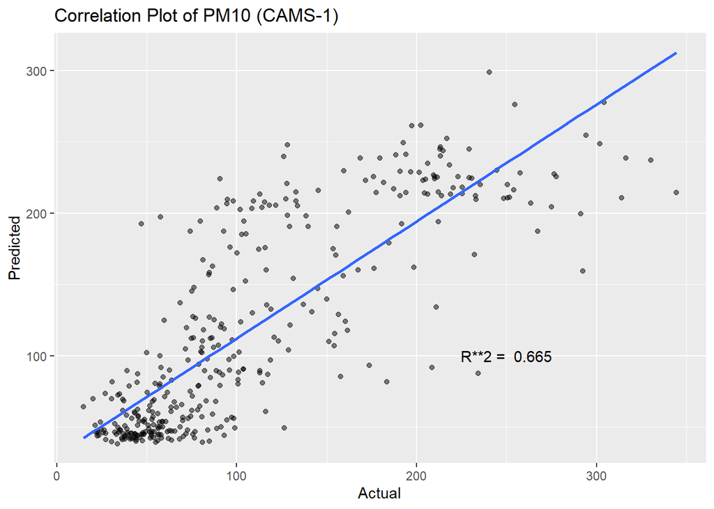

```r
R2 <- caret::postResample(pred = predicted3, obs = actual_test)
r2 <- ggplot(plot_df, aes(actual, predicted))
r2 <- r2 + geom_point(alpha = .5)
r2 <- r2 + annotate(geom = "text", x=250,y=100,  label = paste("R**2 = ", round(R2[2], 3)))
r2 <- r2 + labs(x = "Actual", y = "Predicted", title = "Correlation Plot of PM10 (CAMS-1)")
r2 <- r2 + geom_smooth(se=F, method = "lm")
r2
```

Calculation for weekly averaged data using the developed models involve the same process. The error indices were found to be as follows.

```r
wk_metrics<-readRDS(file = "wk_metrics_df.rds")
wk_metrics
```

```
##            Cor.Coeff     RMSE  Rsquared      MAE
## 3 Neurons  0.8753340 35.78989 0.7662097 26.73503
## 5 Neurons  0.7856564 44.53729 0.6172560 33.03688
## 7 Neurons  0.6631234 60.54809 0.4397326 49.50562
## 9 Neurons  0.6931317 55.41029 0.4804315 42.96192
## 12 Neurons 0.8014242 42.12708 0.6422807 34.04431
## 15 Neurons 0.6836640 49.63679 0.4673964 34.89431
## 20 Neurons 0.6377699 60.18725 0.4067504 47.47433
```

For predicting weekly averaged values, based on the minimum RMSE, the model with 3 neurons performs best. The architecture is shown:

[figure not shown]

```r
wk_im <- load.image('wk_network.jpeg')
plot(wk_im,axes = F)
```

Plot actual vs predicted weekly averaged values

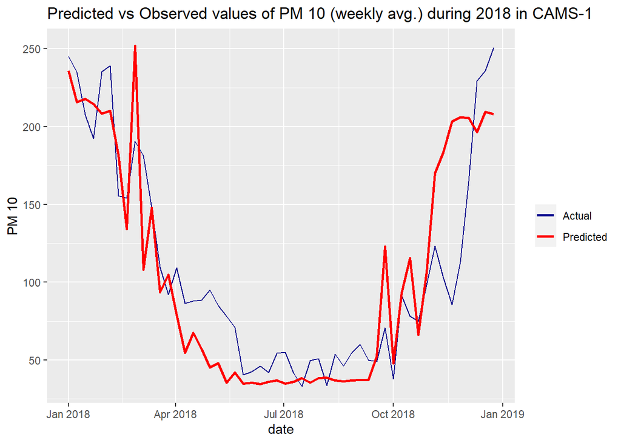

```r
w_10_1<-readRDS(file = "w_10_1.rds")
w_10_1
```

Visual comparison between daily actual vs predicted plots from all stations

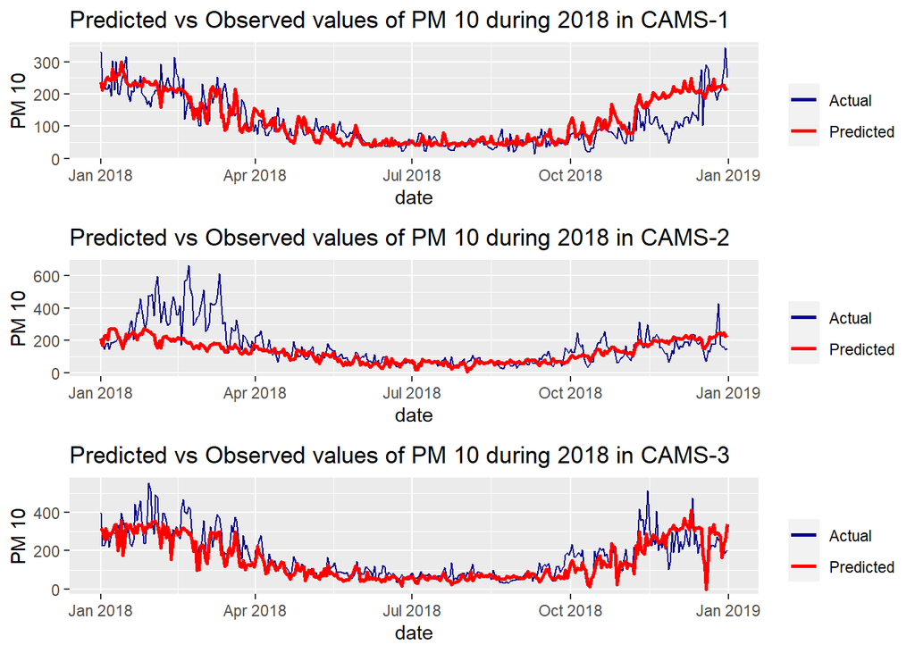

```r
p_10_1<-readRDS(file = "p_10_1.rds")
p_10_2<-readRDS(file = "p_10_2.rds")
p_10_3<-readRDS(file = "p_10_3.rds")

grid.arrange(p_10_1,p_10_2,p_10_3, nrow=3)
```

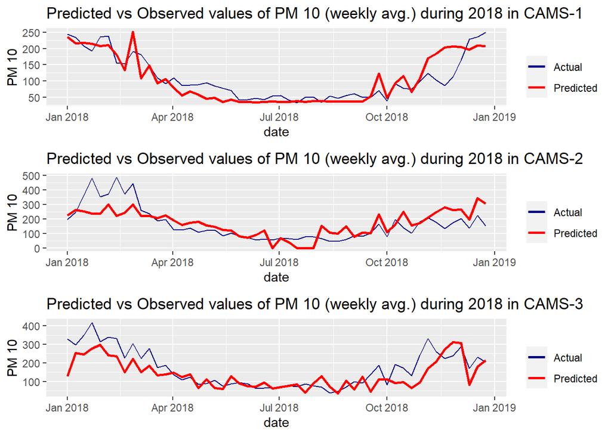

```r
w_10_1<-readRDS(file = "w_10_1.rds")
w_10_2<-readRDS(file = "w_10_2.rds")
w_10_3<-readRDS(file = "w_10_3.rds")

grid.arrange(w_10_1,w_10_2,w_10_3, nrow=3)
```

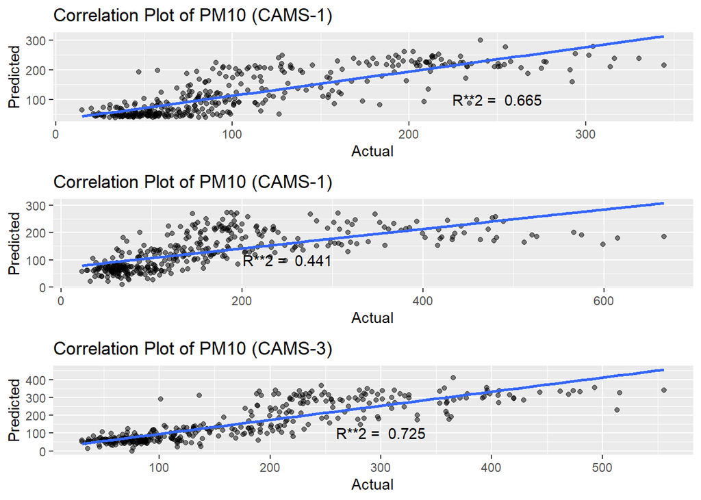

```r
r2_1<-readRDS(file = "r2_1.rds")
r2_2<-readRDS(file = "r2_2.rds")
r2_3<-readRDS(file = "r2_3.rds")

grid.arrange(r2_1,r2_2,r2_3, nrow=3)
```